# PythonForDataAnalysis_2.3

##### applyメソッドを使う方法

```python
def get_top1000(group):
    return group.sort_index(by='births', ascending=False)[:1000]

grouped = names.groupby(['year', 'sex'])
top1000 = grouped.apply(get_top1000)
```

- DataFrame.sort_indexは、デフォルトでは非破壊的。
- オプションinplace=Trueを指定すると破壊的にソートできる。

```python
top1000
```

| year | sex |  | name | sex | births | year | prop |
| --- | --- | --- | --- | --- | --- | --- | --- |
| 1880 | F | 0 | Mary | F | 7065 | 1880 | 0.077643 |
|  |  | 1 | Anna | F | 2604 | 1880 | 0.028618 |
|  |  | 2 | Emma | F | 2003 | 1880 | 0.022013 |
|  |  | 3 | Elizabeth | F | 1939 | 1880 | 0.021309 |
|  |  | 4 | Minnie | F | 1746 | 1880 | 0.019188 |
|  |  | 5 | Margaret | F | 1578 | 1880 | 0.017342 |
|  |  | 6 | Ida | F | 1472 | 1880 | 0.016177 |
|  |  | 7 | Alice | F | 1414 | 1880 | 0.015540 |
|  |  | 8 | Bertha | F | 1320 | 1880 | 0.014507 |
|  |  | 9 | Sarah | F | 1288 | 1880 | 0.014155 |
|  |  | 10 | Annie | F | 1258 | 1880 | 0.013825 |
|  |  | 11 | Clara | F | 1226 | 1880 | 0.013474 |
|  |  | 12 | Ella | F | 1156 | 1880 | 0.012704 |
|  |  | 13 | Florence | F | 1063 | 1880 | 0.011682 |
|  |  | 14 | Cora | F | 1045 | 1880 | 0.011484 |
|  |  | 15 | Martha | F | 1040 | 1880 | 0.011429 |
|  |  | 16 | Laura | F | 1012 | 1880 | 0.011122 |
|  |  | 17 | Nellie | F | 995 | 1880 | 0.010935 |
|  |  | 18 | Grace | F | 982 | 1880 | 0.010792 |
|  |  | 19 | Carrie | F | 949 | 1880 | 0.010429 |
|  |  | 20 | Maude | F | 858 | 1880 | 0.009429 |
|  |  | 21 | Mabel | F | 808 | 1880 | 0.008880 |
|  |  | 22 | Bessie | F | 794 | 1880 | 0.008726 |
|  |  | 23 | Jennie | F | 793 | 1880 | 0.008715 |
|  |  | 24 | Gertrude | F | 787 | 1880 | 0.008649 |
|  |  | 25 | Julia | F | 783 | 1880 | 0.008605 |
|  |  | 26 | Hattie | F | 769 | 1880 | 0.008451 |
|  |  | 27 | Edith | F | 768 | 1880 | 0.008440 |
|  |  | 28 | Mattie | F | 704 | 1880 | 0.007737 |
|  |  | 29 | Rose | F | 700 | 1880 | 0.007693 |
|  |  | 30 | Catherine | F | 688 | 1880 | 0.007561 |
|  |  | 31 | Lillian | F | 672 | 1880 | 0.007385 |
|  |  | 32 | Ada | F | 652 | 1880 | 0.007165 |
|  |  | 33 | Lillie | F | 647 | 1880 | 0.007110 |
|  |  | 34 | Helen | F | 636 | 1880 | 0.006990 |
|  |  | 35 | Jessie | F | 635 | 1880 | 0.006979 |
|  |  | 36 | Louise | F | 635 | 1880 | 0.006979 |
|  |  | 37 | Ethel | F | 633 | 1880 | 0.006957 |
|  |  | 38 | Lula | F | 621 | 1880 | 0.006825 |
|  |  | 39 | Myrtle | F | 615 | 1880 | 0.006759 |
|  |  | 40 | Eva | F | 614 | 1880 | 0.006748 |
|  |  | 41 | Frances | F | 605 | 1880 | 0.006649 |
|  |  | 42 | Lena | F | 603 | 1880 | 0.006627 |
|  |  | 43 | Lucy | F | 591 | 1880 | 0.006495 |
|  |  | 44 | Edna | F | 588 | 1880 | 0.006462 |
|  |  | 45 | Maggie | F | 582 | 1880 | 0.006396 |
|  |  | 46 | Pearl | F | 569 | 1880 | 0.006253 |
|  |  | 47 | Daisy | F | 564 | 1880 | 0.006198 |
|  |  | 48 | Fannie | F | 560 | 1880 | 0.006154 |
|  |  | 49 | Josephine | F | 544 | 1880 | 0.005978 |
|  |  | 50 | Dora | F | 524 | 1880 | 0.005759 |
|  |  | 51 | Rosa | F | 507 | 1880 | 0.005572 |
|  |  | 52 | Katherine | F | 502 | 1880 | 0.005517 |
|  |  | 53 | Agnes | F | 473 | 1880 | 0.005198 |
|  |  | 54 | Marie | F | 471 | 1880 | 0.005176 |
|  |  | 55 | Nora | F | 471 | 1880 | 0.005176 |
|  |  | 56 | May | F | 462 | 1880 | 0.005077 |
|  |  | 57 | Mamie | F | 436 | 1880 | 0.004792 |
|  |  | 58 | Blanche | F | 427 | 1880 | 0.004693 |
|  |  | 59 | Stella | F | 414 | 1880 | 0.004550 |
|  |  |  | ... | ... | ... | ... | ... |

261877 rows × 5 columns

- 元のGroupByオブジェクトのグループ化のキーだった年代、性別と、グループ内のエントリを特定するインデックとで、複合インデックスが作られている。

##### for文を使う方法

```python
pieces = []

for year, group in names.groupby(['year', 'sex']):
    pieces.append(group.sort_index(by='births', ascending=False)[:1000])

top1000 = pd.concat(pieces, ignore_index=True)
```

- DataFrameGroupByオブジェクトに対するfor文は、各グループ対して繰り返し処理を行う。
- ループ変数には、グループ化に用いたキーの値と、グループを表すDataFrameオブジェクトが代入される。
- グループ化に用いたキーが複数の場合は、それらの値のtuppleが代入される。
- したがって、ここで用いているyearという変数には、実際は年と性別のtuppleが代入される。

```python
top1000
```

|  | name | sex | births | year | prop |
| --- | --- | --- | --- | --- | --- |
| 0 | Mary | F | 7065 | 1880 | 0.077643 |
| 1 | Anna | F | 2604 | 1880 | 0.028618 |
| 2 | Emma | F | 2003 | 1880 | 0.022013 |
| 3 | Elizabeth | F | 1939 | 1880 | 0.021309 |
| 4 | Minnie | F | 1746 | 1880 | 0.019188 |
| 5 | Margaret | F | 1578 | 1880 | 0.017342 |
| 6 | Ida | F | 1472 | 1880 | 0.016177 |
| 7 | Alice | F | 1414 | 1880 | 0.015540 |
| 8 | Bertha | F | 1320 | 1880 | 0.014507 |
| 9 | Sarah | F | 1288 | 1880 | 0.014155 |
| 10 | Annie | F | 1258 | 1880 | 0.013825 |
| 11 | Clara | F | 1226 | 1880 | 0.013474 |
| 12 | Ella | F | 1156 | 1880 | 0.012704 |
| 13 | Florence | F | 1063 | 1880 | 0.011682 |
| 14 | Cora | F | 1045 | 1880 | 0.011484 |
| 15 | Martha | F | 1040 | 1880 | 0.011429 |
| 16 | Laura | F | 1012 | 1880 | 0.011122 |
| 17 | Nellie | F | 995 | 1880 | 0.010935 |
| 18 | Grace | F | 982 | 1880 | 0.010792 |
| 19 | Carrie | F | 949 | 1880 | 0.010429 |
| 20 | Maude | F | 858 | 1880 | 0.009429 |
| 21 | Mabel | F | 808 | 1880 | 0.008880 |
| 22 | Bessie | F | 794 | 1880 | 0.008726 |
| 23 | Jennie | F | 793 | 1880 | 0.008715 |
| 24 | Gertrude | F | 787 | 1880 | 0.008649 |
| 25 | Julia | F | 783 | 1880 | 0.008605 |
| 26 | Hattie | F | 769 | 1880 | 0.008451 |
| 27 | Edith | F | 768 | 1880 | 0.008440 |
| 28 | Mattie | F | 704 | 1880 | 0.007737 |
| 29 | Rose | F | 700 | 1880 | 0.007693 |
| 30 | Catherine | F | 688 | 1880 | 0.007561 |
| 31 | Lillian | F | 672 | 1880 | 0.007385 |
| 32 | Ada | F | 652 | 1880 | 0.007165 |
| 33 | Lillie | F | 647 | 1880 | 0.007110 |
| 34 | Helen | F | 636 | 1880 | 0.006990 |
| 35 | Jessie | F | 635 | 1880 | 0.006979 |
| 36 | Louise | F | 635 | 1880 | 0.006979 |
| 37 | Ethel | F | 633 | 1880 | 0.006957 |
| 38 | Lula | F | 621 | 1880 | 0.006825 |
| 39 | Myrtle | F | 615 | 1880 | 0.006759 |
| 40 | Eva | F | 614 | 1880 | 0.006748 |
| 41 | Frances | F | 605 | 1880 | 0.006649 |
| 42 | Lena | F | 603 | 1880 | 0.006627 |
| 43 | Lucy | F | 591 | 1880 | 0.006495 |
| 44 | Edna | F | 588 | 1880 | 0.006462 |
| 45 | Maggie | F | 582 | 1880 | 0.006396 |
| 46 | Pearl | F | 569 | 1880 | 0.006253 |
| 47 | Daisy | F | 564 | 1880 | 0.006198 |
| 48 | Fannie | F | 560 | 1880 | 0.006154 |
| 49 | Josephine | F | 544 | 1880 | 0.005978 |
| 50 | Dora | F | 524 | 1880 | 0.005759 |
| 51 | Rosa | F | 507 | 1880 | 0.005572 |
| 52 | Katherine | F | 502 | 1880 | 0.005517 |
| 53 | Agnes | F | 473 | 1880 | 0.005198 |
| 54 | Marie | F | 471 | 1880 | 0.005176 |
| 55 | Nora | F | 471 | 1880 | 0.005176 |
| 56 | May | F | 462 | 1880 | 0.005077 |
| 57 | Mamie | F | 436 | 1880 | 0.004792 |
| 58 | Blanche | F | 427 | 1880 | 0.004693 |
| 59 | Stella | F | 414 | 1880 | 0.004550 |
|  | ... | ... | ... | ... | ... |

261877 rows × 5 columns

### 2.3.1 名付けの傾向分析

```python
boys = top1000[top1000.sex == 'M']
```

- []内は、Seriesオブジェクトとスカラーの比較で、結果はBool値のSeriesになる。
- DataFrameのブールインデックス参照を使っている。

```python
girls = top1000[top1000.sex == 'F']
```

```python
total_births = top1000.pivot_table('births', rows='year',
                                   cols='name', aggfunc=sum)
```

```python
total_births
```

| name year | Aaden | Aaliyah | Aarav | Aaron | Aarush | Ab | Abagail | Abb | Abbey | Abbie | Abbigail | Abbott | Abby | Abdiel | Abdul | Abdullah | Abe | Abel | Abelardo | Abigail |  |
| --- | --- | --- | --- | --- | --- | --- | --- | --- | --- | --- | --- | --- | --- | --- | --- | --- | --- | --- | --- | --- | --- |
| 1880 | NaN | NaN | NaN | 102 | NaN | NaN | NaN | NaN | NaN | 71 | NaN | NaN | 6 | NaN | NaN | NaN | 50 | 9 | NaN | 12 | ... |
| 1881 | NaN | NaN | NaN | 94 | NaN | NaN | NaN | NaN | NaN | 81 | NaN | NaN | 7 | NaN | NaN | NaN | 36 | 12 | NaN | 8 | ... |
| 1882 | NaN | NaN | NaN | 85 | NaN | NaN | NaN | NaN | NaN | 80 | NaN | NaN | 11 | NaN | NaN | NaN | 50 | 10 | NaN | 14 | ... |
| 1883 | NaN | NaN | NaN | 105 | NaN | NaN | NaN | NaN | NaN | 79 | NaN | NaN | NaN | NaN | NaN | NaN | 43 | 12 | NaN | 11 | ... |
| 1884 | NaN | NaN | NaN | 97 | NaN | NaN | NaN | NaN | NaN | 98 | NaN | NaN | 6 | NaN | NaN | NaN | 45 | 14 | NaN | 13 | ... |
| 1885 | NaN | NaN | NaN | 88 | NaN | 6 | NaN | NaN | NaN | 88 | NaN | NaN | NaN | NaN | NaN | NaN | 47 | 6 | NaN | 9 | ... |
| 1886 | NaN | NaN | NaN | 86 | NaN | NaN | NaN | NaN | NaN | 84 | NaN | NaN | 7 | NaN | NaN | NaN | 50 | 16 | NaN | 15 | ... |
| 1887 | NaN | NaN | NaN | 78 | NaN | NaN | NaN | NaN | NaN | 104 | NaN | NaN | NaN | NaN | NaN | NaN | 37 | 11 | NaN | 13 | ... |
| 1888 | NaN | NaN | NaN | 90 | NaN | NaN | NaN | NaN | NaN | 137 | NaN | 6 | 9 | NaN | NaN | NaN | 46 | 8 | NaN | 18 | ... |
| 1889 | NaN | NaN | NaN | 85 | NaN | NaN | NaN | NaN | NaN | 107 | NaN | NaN | NaN | NaN | NaN | NaN | 39 | 9 | NaN | 20 | ... |
| 1890 | NaN | NaN | NaN | 96 | NaN | NaN | NaN | 6 | NaN | 140 | NaN | NaN | NaN | NaN | NaN | NaN | 49 | 14 | NaN | NaN | ... |
| 1891 | NaN | NaN | NaN | 69 | NaN | NaN | NaN | NaN | NaN | 124 | NaN | NaN | 12 | NaN | NaN | NaN | 40 | 10 | NaN | 11 | ... |
| 1892 | NaN | NaN | NaN | 95 | NaN | NaN | NaN | NaN | NaN | 119 | NaN | NaN | NaN | NaN | NaN | NaN | 53 | 8 | NaN | 11 | ... |
| 1893 | NaN | NaN | NaN | 81 | NaN | NaN | NaN | NaN | NaN | 115 | NaN | NaN | NaN | NaN | NaN | NaN | 43 | 13 | NaN | 21 | ... |
| 1894 | NaN | NaN | NaN | 79 | NaN | NaN | NaN | NaN | NaN | 118 | NaN | NaN | NaN | NaN | NaN | NaN | 50 | 15 | NaN | 13 | ... |
| 1895 | NaN | NaN | NaN | 94 | NaN | NaN | NaN | NaN | NaN | 92 | NaN | NaN | NaN | NaN | NaN | NaN | 54 | NaN | NaN | 15 | ... |
| 1896 | NaN | NaN | NaN | 69 | NaN | NaN | NaN | NaN | NaN | 121 | NaN | NaN | NaN | NaN | NaN | NaN | 51 | 15 | NaN | 15 | ... |
| 1897 | NaN | NaN | NaN | 87 | NaN | NaN | NaN | NaN | NaN | 97 | NaN | NaN | NaN | NaN | NaN | NaN | 58 | 12 | NaN | 15 | ... |
| 1898 | NaN | NaN | NaN | 89 | NaN | NaN | NaN | NaN | NaN | 120 | NaN | NaN | NaN | NaN | NaN | NaN | 67 | 10 | NaN | NaN | ... |
| 1899 | NaN | NaN | NaN | 71 | NaN | NaN | NaN | NaN | NaN | 87 | NaN | NaN | NaN | NaN | NaN | NaN | 39 | 15 | NaN | NaN | ... |
| 1900 | NaN | NaN | NaN | 104 | NaN | NaN | NaN | NaN | NaN | 112 | NaN | NaN | NaN | NaN | NaN | NaN | 56 | 15 | NaN | NaN | ... |
| 1901 | NaN | NaN | NaN | 80 | NaN | NaN | NaN | NaN | NaN | 87 | NaN | NaN | NaN | NaN | NaN | NaN | 48 | 13 | NaN | 13 | ... |
| 1902 | NaN | NaN | NaN | 78 | NaN | NaN | NaN | NaN | NaN | 91 | NaN | NaN | NaN | NaN | NaN | NaN | 54 | 11 | NaN | 18 | ... |
| 1903 | NaN | NaN | NaN | 93 | NaN | NaN | NaN | NaN | NaN | 91 | NaN | NaN | NaN | NaN | NaN | NaN | 58 | 14 | NaN | 20 | ... |
| 1904 | NaN | NaN | NaN | 117 | NaN | NaN | NaN | NaN | NaN | 80 | NaN | NaN | NaN | NaN | NaN | NaN | 52 | 10 | NaN | NaN | ... |
| 1905 | NaN | NaN | NaN | 96 | NaN | NaN | NaN | NaN | NaN | 73 | NaN | NaN | NaN | NaN | NaN | NaN | 65 | NaN | NaN | NaN | ... |
| 1906 | NaN | NaN | NaN | 96 | NaN | NaN | NaN | NaN | NaN | 72 | NaN | NaN | NaN | NaN | NaN | NaN | 50 | 11 | NaN | 15 | ... |
| 1907 | NaN | NaN | NaN | 130 | NaN | NaN | NaN | NaN | NaN | 79 | NaN | NaN | NaN | NaN | NaN | NaN | 65 | 10 | NaN | NaN | ... |
| 1908 | NaN | NaN | NaN | 114 | NaN | NaN | NaN | NaN | NaN | 84 | NaN | NaN | NaN | NaN | NaN | NaN | 57 | 15 | NaN | NaN | ... |
| 1909 | NaN | NaN | NaN | 142 | NaN | NaN | NaN | NaN | NaN | 57 | NaN | NaN | NaN | NaN | NaN | NaN | 67 | 16 | NaN | NaN | ... |
| 1910 | NaN | NaN | NaN | 145 | NaN | NaN | NaN | NaN | NaN | 79 | NaN | NaN | NaN | NaN | NaN | NaN | 74 | NaN | NaN | NaN | ... |
| 1911 | NaN | NaN | NaN | 187 | NaN | NaN | NaN | NaN | NaN | 77 | NaN | NaN | NaN | NaN | NaN | NaN | 94 | 30 | NaN | NaN | ... |
| 1912 | NaN | NaN | NaN | 303 | NaN | NaN | NaN | NaN | NaN | 90 | NaN | NaN | NaN | NaN | NaN | NaN | 172 | 40 | NaN | NaN | ... |
| 1913 | NaN | NaN | NaN | 417 | NaN | NaN | NaN | NaN | NaN | 121 | NaN | NaN | NaN | NaN | NaN | NaN | 202 | 48 | NaN | NaN | ... |
| 1914 | NaN | NaN | NaN | 485 | NaN | NaN | NaN | NaN | NaN | 99 | NaN | NaN | NaN | NaN | NaN | NaN | 225 | 51 | NaN | NaN | ... |
| 1915 | NaN | NaN | NaN | 553 | NaN | NaN | NaN | NaN | NaN | 124 | NaN | NaN | NaN | NaN | NaN | NaN | 271 | 64 | NaN | NaN | ... |
| 1916 | NaN | NaN | NaN | 584 | NaN | NaN | NaN | NaN | NaN | 146 | NaN | NaN | NaN | NaN | NaN | NaN | 261 | 62 | NaN | NaN | ... |
| 1917 | NaN | NaN | NaN | 597 | NaN | NaN | NaN | NaN | NaN | 136 | NaN | NaN | NaN | NaN | NaN | NaN | 280 | 86 | NaN | NaN | ... |
| 1918 | NaN | NaN | NaN | 656 | NaN | NaN | NaN | NaN | NaN | 120 | NaN | NaN | NaN | NaN | NaN | NaN | 256 | 76 | NaN | NaN | ... |
| 1919 | NaN | NaN | NaN | 645 | NaN | NaN | NaN | NaN | NaN | 147 | NaN | NaN | NaN | NaN | NaN | NaN | 265 | 91 | NaN | NaN | ... |
| 1920 | NaN | NaN | NaN | 668 | NaN | NaN | NaN | NaN | NaN | 98 | NaN | NaN | NaN | NaN | NaN | NaN | 206 | 79 | NaN | NaN | ... |
| 1921 | NaN | NaN | NaN | 696 | NaN | NaN | NaN | NaN | NaN | 134 | NaN | NaN | NaN | NaN | NaN | NaN | 230 | 84 | NaN | NaN | ... |
| 1922 | NaN | NaN | NaN | 700 | NaN | NaN | NaN | NaN | NaN | 142 | NaN | NaN | NaN | NaN | NaN | NaN | 176 | 91 | NaN | NaN | ... |
| 1923 | NaN | NaN | NaN | 616 | NaN | NaN | NaN | NaN | NaN | 129 | NaN | NaN | NaN | NaN | NaN | NaN | 174 | 73 | NaN | NaN | ... |
| 1924 | NaN | NaN | NaN | 683 | NaN | NaN | NaN | NaN | NaN | 96 | NaN | NaN | NaN | NaN | NaN | NaN | 174 | 111 | NaN | NaN | ... |
| 1925 | NaN | NaN | NaN | 644 | NaN | NaN | NaN | NaN | NaN | 128 | NaN | NaN | NaN | NaN | NaN | NaN | 117 | 83 | NaN | NaN | ... |
| 1926 | NaN | NaN | NaN | 593 | NaN | NaN | NaN | NaN | NaN | 105 | NaN | NaN | NaN | NaN | NaN | NaN | 134 | 101 | NaN | NaN | ... |
| 1927 | NaN | NaN | NaN | 546 | NaN | NaN | NaN | NaN | NaN | 103 | NaN | NaN | NaN | NaN | NaN | NaN | 139 | 78 | NaN | NaN | ... |
| 1928 | NaN | NaN | NaN | 557 | NaN | NaN | NaN | NaN | NaN | 92 | NaN | NaN | NaN | NaN | NaN | NaN | 90 | 85 | NaN | NaN | ... |
| 1929 | NaN | NaN | NaN | 469 | NaN | NaN | NaN | NaN | NaN | 78 | NaN | NaN | NaN | NaN | NaN | NaN | 61 | 96 | NaN | NaN | ... |
| 1930 | NaN | NaN | NaN | 500 | NaN | NaN | NaN | NaN | NaN | 77 | NaN | NaN | NaN | NaN | NaN | NaN | 85 | 123 | NaN | NaN | ... |
| 1931 | NaN | NaN | NaN | 458 | NaN | NaN | NaN | NaN | NaN | 71 | NaN | NaN | NaN | NaN | NaN | NaN | 79 | 93 | NaN | NaN | ... |
| 1932 | NaN | NaN | NaN | 514 | NaN | NaN | NaN | NaN | NaN | 57 | NaN | NaN | NaN | NaN | NaN | NaN | 83 | 94 | NaN | NaN | ... |
| 1933 | NaN | NaN | NaN | 460 | NaN | NaN | NaN | NaN | NaN | 64 | NaN | NaN | NaN | NaN | NaN | NaN | 68 | 96 | NaN | NaN | ... |
| 1934 | NaN | NaN | NaN | 478 | NaN | NaN | NaN | NaN | NaN | 60 | NaN | NaN | NaN | NaN | NaN | NaN | 75 | 93 | NaN | NaN | ... |
| 1935 | NaN | NaN | NaN | 461 | NaN | NaN | NaN | NaN | NaN | 60 | NaN | NaN | NaN | NaN | NaN | NaN | 59 | 92 | NaN | NaN | ... |
| 1936 | NaN | NaN | NaN | 443 | NaN | NaN | NaN | NaN | NaN | NaN | NaN | NaN | NaN | NaN | NaN | NaN | 70 | 74 | NaN | NaN | ... |
| 1937 | NaN | NaN | NaN | 464 | NaN | NaN | NaN | NaN | NaN | 52 | NaN | NaN | NaN | NaN | NaN | NaN | 64 | 91 | NaN | NaN | ... |
| 1938 | NaN | NaN | NaN | 478 | NaN | NaN | NaN | NaN | NaN | 57 | NaN | NaN | NaN | NaN | NaN | NaN | 55 | 87 | NaN | NaN | ... |
| 1939 | NaN | NaN | NaN | 471 | NaN | NaN | NaN | NaN | NaN | 69 | NaN | NaN | NaN | NaN | NaN | NaN | 56 | 95 | NaN | 53 | ... |
|  | ... | ... | ... | ... | ... | ... | ... | ... | ... | ... | ... | ... | ... | ... | ... | ... | ... | ... | ... | ... |  |

131 rows × 6865 columns

```python
subset = total_births[['John', 'Harry', 'Mary', 'Marilyn']]
```

- DataFrameオブジェクトのインデックス参照の一つ。

[output not shown]

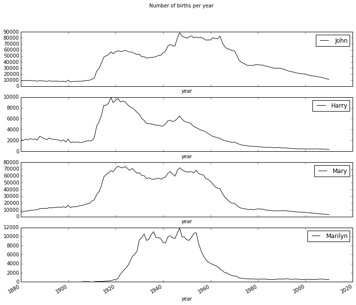

```python
subset.plot(subplots=True, figsize=(12, 10), grid=False,
            title="Number of births per year")
```

- オプション `subplots=True` で、系列ごとに分けてプロットできる。

#### 2.3.1.1 多様化していく名付け

多様性を表す指標として、次の2つを考える。

1. 上位1000件の名前が全体に占める割合
2. 上位50%を占める名前の件数

##### (1) 上位1000件の名前が全体に占める割合

```python
table = top1000.pivot_table('prop', rows='year',
                            cols='sex', aggfunc=sum)
```

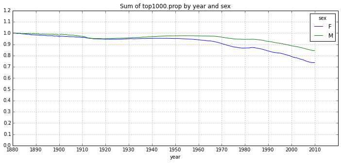

```python
table.plot(title='Sum of top1000.prop by year and sex',
           yticks=np.linspace(0, 1.2, 13), xticks=range(1880, 2020, 10),
           figsize=(12, 5))
```

##### (2) 上位50%を占める名前の件数

```python
df = boys[boys.year == 2010]
```

```python
df
```

|  | name | sex | births | year | prop |
| --- | --- | --- | --- | --- | --- |
| 260877 | Jacob | M | 21875 | 2010 | 0.011523 |
| 260878 | Ethan | M | 17866 | 2010 | 0.009411 |
| 260879 | Michael | M | 17133 | 2010 | 0.009025 |
| 260880 | Jayden | M | 17030 | 2010 | 0.008971 |
| 260881 | William | M | 16870 | 2010 | 0.008887 |
| 260882 | Alexander | M | 16634 | 2010 | 0.008762 |
| 260883 | Noah | M | 16281 | 2010 | 0.008576 |
| 260884 | Daniel | M | 15679 | 2010 | 0.008259 |
| 260885 | Aiden | M | 15403 | 2010 | 0.008114 |
| 260886 | Anthony | M | 15364 | 2010 | 0.008093 |
| 260887 | Joshua | M | 15238 | 2010 | 0.008027 |
| 260888 | Mason | M | 14728 | 2010 | 0.007758 |
| 260889 | Christopher | M | 14135 | 2010 | 0.007446 |
| 260890 | Andrew | M | 14093 | 2010 | 0.007424 |
| 260891 | David | M | 14042 | 2010 | 0.007397 |
| 260892 | Matthew | M | 13954 | 2010 | 0.007350 |
| 260893 | Logan | M | 13943 | 2010 | 0.007345 |
| 260894 | Elijah | M | 13735 | 2010 | 0.007235 |
| 260895 | James | M | 13714 | 2010 | 0.007224 |
| 260896 | Joseph | M | 13657 | 2010 | 0.007194 |
| 260897 | Gabriel | M | 12722 | 2010 | 0.006701 |
| 260898 | Benjamin | M | 12280 | 2010 | 0.006469 |
| 260899 | Ryan | M | 11886 | 2010 | 0.006261 |
| 260900 | Samuel | M | 11776 | 2010 | 0.006203 |
| 260901 | Jackson | M | 11693 | 2010 | 0.006159 |
| 260902 | John | M | 11424 | 2010 | 0.006018 |
| 260903 | Nathan | M | 11269 | 2010 | 0.005936 |
| 260904 | Jonathan | M | 11028 | 2010 | 0.005809 |
| 260905 | Christian | M | 10965 | 2010 | 0.005776 |
| 260906 | Liam | M | 10852 | 2010 | 0.005716 |
| 260907 | Dylan | M | 10455 | 2010 | 0.005507 |
| 260908 | Landon | M | 10400 | 2010 | 0.005478 |
| 260909 | Caleb | M | 10359 | 2010 | 0.005457 |
| 260910 | Tyler | M | 10357 | 2010 | 0.005456 |
| 260911 | Lucas | M | 10294 | 2010 | 0.005423 |
| 260912 | Evan | M | 9655 | 2010 | 0.005086 |
| 260913 | Gavin | M | 9551 | 2010 | 0.005031 |
| 260914 | Nicholas | M | 9549 | 2010 | 0.005030 |
| 260915 | Isaac | M | 9254 | 2010 | 0.004875 |
| 260916 | Brayden | M | 9046 | 2010 | 0.004765 |
| 260917 | Luke | M | 8767 | 2010 | 0.004618 |
| 260918 | Angel | M | 8716 | 2010 | 0.004591 |
| 260919 | Brandon | M | 8473 | 2010 | 0.004463 |
| 260920 | Jack | M | 8457 | 2010 | 0.004455 |
| 260921 | Isaiah | M | 8443 | 2010 | 0.004447 |
| 260922 | Jordan | M | 8156 | 2010 | 0.004296 |
| 260923 | Owen | M | 8136 | 2010 | 0.004286 |
| 260924 | Carter | M | 8101 | 2010 | 0.004267 |
| 260925 | Connor | M | 7991 | 2010 | 0.004209 |
| 260926 | Justin | M | 7792 | 2010 | 0.004105 |
| 260927 | Jose | M | 7656 | 2010 | 0.004033 |
| 260928 | Jeremiah | M | 7645 | 2010 | 0.004027 |
| 260929 | Julian | M | 7534 | 2010 | 0.003969 |
| 260930 | Robert | M | 7471 | 2010 | 0.003935 |
| 260931 | Aaron | M | 7374 | 2010 | 0.003884 |
| 260932 | Adrian | M | 7354 | 2010 | 0.003874 |
| 260933 | Wyatt | M | 7319 | 2010 | 0.003855 |
| 260934 | Kevin | M | 7278 | 2010 | 0.003834 |
| 260935 | Hunter | M | 7271 | 2010 | 0.003830 |
| 260936 | Cameron | M | 7137 | 2010 | 0.003760 |
|  | ... | ... | ... | ... | ... |

1000 rows × 5 columns

```python
prop_cumsum = df.sort_index(by='prop', ascending=False).prop.cumsum()
```

- Series.cumsumは、累積和を求めるメソッド。
- [リファレンスマニュアル](http://pandas.pydata.org/pandas-docs/version/0.13.1/generated/pandas.Series.cumsum.html)にはcumsumの戻り値はスカラーと書かれているが、実際はSeries。

```python
prop_cumsum[:10]
```

```
260877    0.011523
260878    0.020934
260879    0.029959
260880    0.038930
260881    0.047817
260882    0.056579
260883    0.065155
260884    0.073414
260885    0.081528
260886    0.089621
Name: prop, dtype: float64
```

```python
prop_cumsum.values.searchsorted(0.5)
```

```
116
```

- 書籍ではprop_cumsum.searchsorted(0.5)としているが、新しい版のpandasではsearchsortedはSeriesのメソッドではない。
- Series.valuesメソッドでndarrayに変換してndarray.searchsortedを使うか、np.searchsorted(prop_cumsum, 0.5)とする。

```python
df = boys[boys.year == 1900]
```

```python
in1900 = df.sort_index(by='prop', ascending=False).prop.cumsum()
```

```python
in1900.values.searchsorted(0.5) + 1
```

```
25
```

```python
def get_quantile_count(group, q=0.5):
    group = group.sort_index(by='prop', ascending=False)
    return group.prop.cumsum().values.searchsorted(q) + 1

diversity_tmp = top1000.groupby(['year', 'sex']).apply(get_quantile_count)
diversity = diversity_tmp.unstack('sex')
```

```python
diversity_tmp
```

```
year  sex
1880  F      38
      M      14
1881  F      38
      M      14
1882  F      38
      M      15
1883  F      39
      M      15
1884  F      39
      M      16
1885  F      40
      M      16
1886  F      41
      M      16
1887  F      41
...
2003  M       87
2004  F      191
      M       92
2005  F      199
      M       96
2006  F      209
      M       99
2007  F      223
      M      103
2008  F      234
      M      109
2009  F      241
      M      114
2010  F      246
      M      117
Length: 262, dtype: int64
```

```python
diversity.head()
```

| sex year | F | M |
| --- | --- | --- |
| 1880 | 38 | 14 |
| 1881 | 38 | 14 |
| 1882 | 38 | 15 |
| 1883 | 39 | 15 |
| 1884 | 39 | 16 |

5 rows × 2 columns

- quantileは、統計用語で、分位数、分位点、分位値などと訳される。中央値、四分位数等の総称。
- get_quantile_countは、出生数の中央に位置する名前そのものではなく、その名前の順位を返す。
- diversityは、多様性。
- ここでのapplyの結果は、グループごとの上位50%を占める名前件数から成るSeriesになる。
- Series.unstackは、マルチインデックスのSeriesをDataFrameに変換する。  
  ここでは、applyが返すSeriesが年代と性別でインデックス付けされているので、  
  年代を行の、性別を列のインデックスとするDataFrameが得られる。

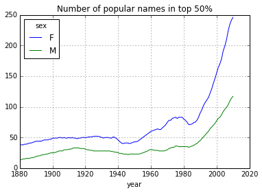

```python
diversity.plot(title="Number of popular names in top 50%")
```

#### 2.3.1.2 名前「末尾一文字」の変化

```python
# 名前列から末尾文字を抽出
get_last_letter = lambda x: x[-1]
last_letters = names.name.map(get_last_letter)
last_letters.name = 'last_letter'

table = names.pivot_table('births', rows=last_letters,
                          cols=['sex', 'year'], aggfunc=sum)
```

```python
last_letters.head(5)
```

```
0    y
1    a
2    a
3    h
4    e
Name: last_letter, dtype: object
```

```python
last_letters.tail(5)
```

```
1690779    e
1690780    e
1690781    s
1690782    n
1690783    x
Name: last_letter, dtype: object
```

```python
subtable = table.reindex(columns=[1910, 1960, 2010], level='year')
```

```python
subtable.head()
```

| sex year last_letter | F 1910 | F 1960 | F 2010 | M 1910 | M 1960 | M 2010 |
| --- | --- | --- | --- | --- | --- | --- |
| a | 108376 | 691247 | 670605 | 977 | 5204 | 28438 |
| b | NaN | 694 | 450 | 411 | 3912 | 38859 |
| c | 5 | 49 | 946 | 482 | 15476 | 23125 |
| d | 6750 | 3729 | 2607 | 22111 | 262112 | 44398 |
| e | 133569 | 435013 | 313833 | 28655 | 178823 | 129012 |

5 rows × 6 columns

- tableは、行が'last_letter'で、列が'sex'と'year'で、インデックス付けされたDataFrameになっている。
- DataFrame.reindexは、インデックスを指定して行、列を追加、削除する。
- オプション `columns=[...]` は、新しいDataFrameに含まれる列のインデックスを指定する。
- オプション `level='year'` は、`column`で指定した値が、複合インデックスの'year'に対応していることを示す。

```python
subtable.sum()
```

```
sex  year
F    1910     396416
     1960    2022062
     2010    1759010
M    1910     194198
     1960    2132588
     2010    1898382
dtype: float64
```

##### 末尾文字の比率を計算

```python
letter_prop = subtable / subtable.sum().astype(float)
```

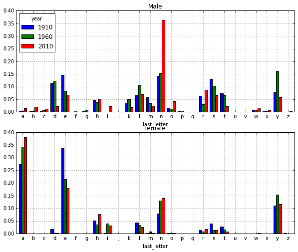

```python
import matplotlib.pyplot as plt

fig, axes = plt.subplots(2, 1, figsize=(10, 8))
letter_prop['M'].plot(kind='bar', rot=0, ax=axes[0], title='Male')
letter_prop['F'].plot(kind='bar', rot=0, ax=axes[1], title='Female',
                      legend=False)
```

##### 男の子の末尾文字「d」「n」「y」

```python
letter_prop = table / table.sum().astype(float)
```

```python
dny_ts = letter_prop.ix[['d', 'n', 'y'], 'M'].T
```

```python
dny_ts.head()
```

| year | d | n | y |
| --- | --- | --- | --- |
| 1880 | 0.083055 | 0.153213 | 0.075760 |
| 1881 | 0.083247 | 0.153214 | 0.077451 |
| 1882 | 0.085340 | 0.149560 | 0.077537 |
| 1883 | 0.084066 | 0.151646 | 0.079144 |
| 1884 | 0.086120 | 0.149915 | 0.080405 |

5 rows × 3 columns

- DataFrame.ixは、使い方がよく分からない。マルチインデックスを扱えるということだが。。。

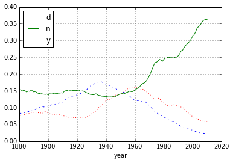

```python
dny_ts.plot(style={'d':'-.','n':'-','y':':'})
```

#### 2.3.1.3 男の子の名前として定着した女の子の名前(あるいはその逆)

```python
all_names = top1000.name.unique()
```

pandas.Series.uniqueはndarrayを返す。

```python
mask = np.array(['lesl' in x.lower() for x in all_names])
```

```python
lesley_like = all_names[mask]
```

ndarrayのブールインデックス参照(p.101)を使っている。

```python
lesley_like
```

```
array(['Leslie', 'Lesley', 'Leslee', 'Lesli', 'Lesly'], dtype=object)
```

```python
filtered = top1000[top1000.name.isin(lesley_like)]
```

- pandas.Series.isinはBool値のSeriesを返す。
- 今度は、DataFrameのブールインデックス参照を使っている。

```python
filtered.groupby('name').births.sum()
```

```
name
Leslee      1082
Lesley     35022
Lesli        929
Leslie    370429
Lesly      10067
Name: births, dtype: int64
```

```python
filtered.head(10)
```

|  | name | sex | births | year | prop |
| --- | --- | --- | --- | --- | --- |
| 636 | Leslie | F | 8 | 1880 | 0.000088 |
| 1108 | Leslie | M | 79 | 1880 | 0.000715 |
| 2445 | Leslie | F | 11 | 1881 | 0.000120 |
| 3014 | Leslie | M | 92 | 1881 | 0.000913 |
| 4515 | Leslie | F | 9 | 1882 | 0.000083 |
| 4994 | Leslie | M | 122 | 1882 | 0.001073 |
| 5721 | Lesley | M | 6 | 1882 | 0.000053 |
| 6642 | Leslie | F | 7 | 1883 | 0.000062 |
| 6985 | Leslie | M | 120 | 1883 | 0.001147 |
| 7781 | Lesley | M | 5 | 1883 | 0.000048 |

10 rows × 5 columns

```python
filtered.tail(10)
```

|  | name | sex | births | year | prop |
| --- | --- | --- | --- | --- | --- |
| 252621 | Lesley | F | 370 | 2006 | 0.000195 |
| 254003 | Leslie | F | 2689 | 2007 | 0.001403 |
| 254304 | Lesly | F | 765 | 2007 | 0.000399 |
| 254693 | Lesley | F | 351 | 2007 | 0.000183 |
| 256023 | Leslie | F | 2323 | 2008 | 0.001233 |
| 256327 | Lesly | F | 699 | 2008 | 0.000371 |
| 258036 | Leslie | F | 1975 | 2009 | 0.001081 |
| 258379 | Lesly | F | 598 | 2009 | 0.000327 |
| 260073 | Leslie | F | 1558 | 2010 | 0.000886 |
| 260456 | Lesly | F | 502 | 2010 | 0.000285 |

10 rows × 5 columns

- 昔は男女ともLesleyっぽい名前の子がいたが、近年は女の子しかいないことが分かる。

```python
table_tmp = filtered.pivot_table('births', rows='year',
                                 cols='sex', aggfunc='sum')
```

```python
table_tmp.head()
```

| sex year | F | M |
| --- | --- | --- |
| 1880 | 8 | 79 |
| 1881 | 11 | 92 |
| 1882 | 9 | 128 |
| 1883 | 7 | 125 |
| 1884 | 15 | 125 |

5 rows × 2 columns

```python
table_tmp.tail()
```

| sex year | F | M |
| --- | --- | --- |
| 2006 | 4166 | NaN |
| 2007 | 3805 | NaN |
| 2008 | 3022 | NaN |
| 2009 | 2573 | NaN |
| 2010 | 2060 | NaN |

5 rows × 2 columns

```python
table = table_tmp.div(table_tmp.sum(1), axis=0)
```

```python
table.head()
```

| sex year | F | M |
| --- | --- | --- |
| 1880 | 0.091954 | 0.908046 |
| 1881 | 0.106796 | 0.893204 |
| 1882 | 0.065693 | 0.934307 |
| 1883 | 0.053030 | 0.946970 |
| 1884 | 0.107143 | 0.892857 |

5 rows × 2 columns

```python
table.tail()
```

| sex year | F | M |
| --- | --- | --- |
| 2006 | 1 | NaN |
| 2007 | 1 | NaN |
| 2008 | 1 | NaN |
| 2009 | 1 | NaN |
| 2010 | 1 | NaN |

5 rows × 2 columns

- DataFrame.sum(1)は、横方向に和をとる。ここでは年代ごとのLesleyっぽい名前の男女の出生数の和。
- DataFrame.divは、除算を行う。除数としてDataFrame、Series、スカラーを与えることができる。
- オプション `axis` は、除数としてSeriesを与えたとき、列ベクトルのように扱うか(0)、行ベクトルのように扱うか(1)を指定する。
- 'M'列の値がNaNなのは、pivot_tableで和を取ったときに、該当するエントリが存在しなかったため。

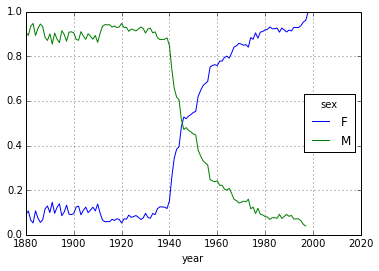

```python
table.plot()
```

##### 1940年以降、女の子のLeslieが急増し、男の子を逆転している。なぜか？

1940年にThe Letterという映画が公開されており、  
その主人公がLeslieという名の女性。  
おそらくその映画がヒットしLeslieが女性の名前として認知されたのだろう。